# Ensemble Verification

Andrew Singleton

17/02/2022

```r
library(harp)
library(here)
library(dplyr)
```

# Ensemble verification works like deterministic

In fact, the work flow is exactly the same! So we start with reading in the forecast SQLite (FCTABLE) files. We are going to compare two models - IFSENS, and an experiment with HarmonEPS called REF. One thing to note is that the FCTABLE files for IFSENS were produced with an old version of harp where the default was to have one file for each lead time, so we need to have different templates for the file names. Fortunately we have some built in template names so we don’t have to write it out in full! You can see the templates with `show_file_templates()` and then choose a specific number to see in detail - we want the “fctable” and “fctable_eps” templates.

```r
show_file_templates()
```

```
## # A tibble: 34 × 2
##    template_name          template
##    <chr>                  <chr>
##  1 arome_arctic_extracted /lustre/storeB/immutable/archive/projects/metproducti…
##  2 arome_arctic_full      /lustre/storeB/immutable/archive/projects/metproducti…
##  3 arome_arctic_sfx       /lustre/storeB/immutable/archive/projects/metproducti…
##  4 fctable                {file_path}/{fcst_model}/{YYYY}/{MM}/FCTABLE_{paramet…
##  5 fctable_det            {file_path}/{det_model}/{YYYY}/{MM}/FCTABLE_{paramete…
##  6 fctable_eps            {file_path}/{eps_model}/{YYYY}/{MM}/FCTABLE_{paramete…
##  7 fctable_eps_all_cycles {file_path}/{eps_model}/{YYYY}/{MM}/FCTABLE_{paramete…
##  8 fctable_eps_all_leads  {file_path}/{eps_model}/{YYYY}/{MM}/FCTABLE_{paramete…
##  9 glameps_grib           {file_path}/{eps_model}/{sub_model}/{YYYY}/{MM}/{DD}/…
## 10 harmoneps_grib         {file_path}/{YYYY}/{MM}/{DD}/{HH}/mbr{MBR3}/fc{YYYY}{…
## 11 harmoneps_grib_fp      {file_path}/{YYYY}/{MM}/{DD}/{HH}/mbr{MBR3}/fc{YYYY}{…
## 12 harmoneps_grib_sfx     {file_path}/{YYYY}/{MM}/{DD}/{HH}/mbr{MBR3}/fc{YYYY}{…
```

[output cut: 22 more lines]

```r
show_file_templates(4)
```

```
##
## template_name:
##  fctable
##
## template:
##  {file_path}/{fcst_model}/{YYYY}/{MM}/FCTABLE_{parameter}_{YYYY}{MM}_{HH}.sqlite
```

```r
show_file_templates(6)
```

```
##
## template_name:
##  fctable_eps
##
## template:
##  {file_path}/{eps_model}/{YYYY}/{MM}/FCTABLE_{parameter}_{YYYY}{MM}_{HH}+{LDT3}.sqlite
```

We are going to verify for 6 hour accumulated precipitation.

```r
pcp6h <- read_point_forecast(
  dttm          = seq_dttm(2018030800, 2018033100, "1d"),
  fcst_model    = c("REF", "IFSENS"),
  fcst_type     = "eps",
  parameter     = "AccPcp6h",
  file_path     = here("data/FCTABLE"),
  file_template = list(
    REF    = "fctable",
    IFSENS = "fctable_eps"
  )
)
```

And now select the common cases

```r
pcp6h <- common_cases(pcp6h)
```

And now the observations

```r
pcp6h_obs <- read_point_obs(
  dttm       = unique_valid_dttm(pcp6h),
  parameter  = "AccPcp6h",
  stations   = unique_stations(pcp6h),
  obs_path   = here("data/OBSTABLE")
)
```

We see that 1 observation was removed due to the gross error check. The output of `read_point_obs()` has some attributes - we can see them using the `attributes()` function and pick out a specific one with `attr()`

```r
attributes(pcp6h_obs)
```

[output not shown]

[output cut: 387 more lines]

```r
attr(pcp6h_obs, "bad_obs")
```

```
## # A tibble: 1 × 7
##   valid_dttm            SID   lon   lat  elev units  AccPcp6h
##   <dttm>              <int> <dbl> <dbl> <dbl> <chr>     <dbl>
## 1 2018-03-24 18:00:00  1062  25.0  76.5    10 kg/m^2     -0.9
```

Now we can join the forecasts and observations together

```r
pcp6h <- join_to_fcst(pcp6h, pcp6h_obs)
```

We can do scatter plot - by default it will split it up by member

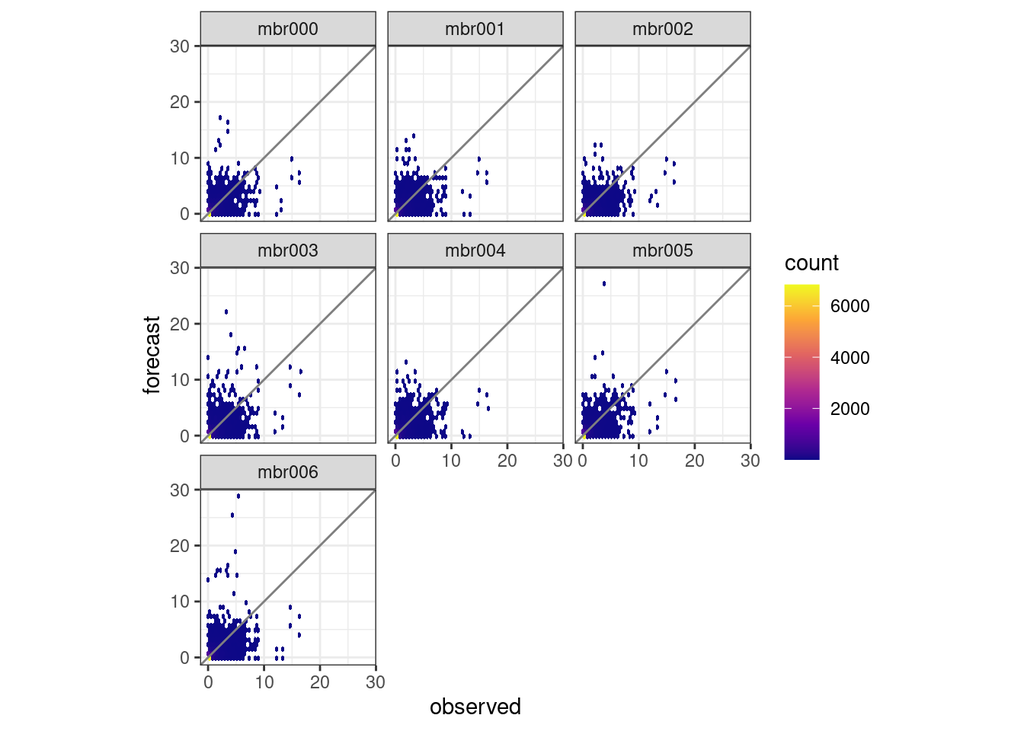

```r
plot_scatter(pcp6h, REF, AccPcp6h)
```

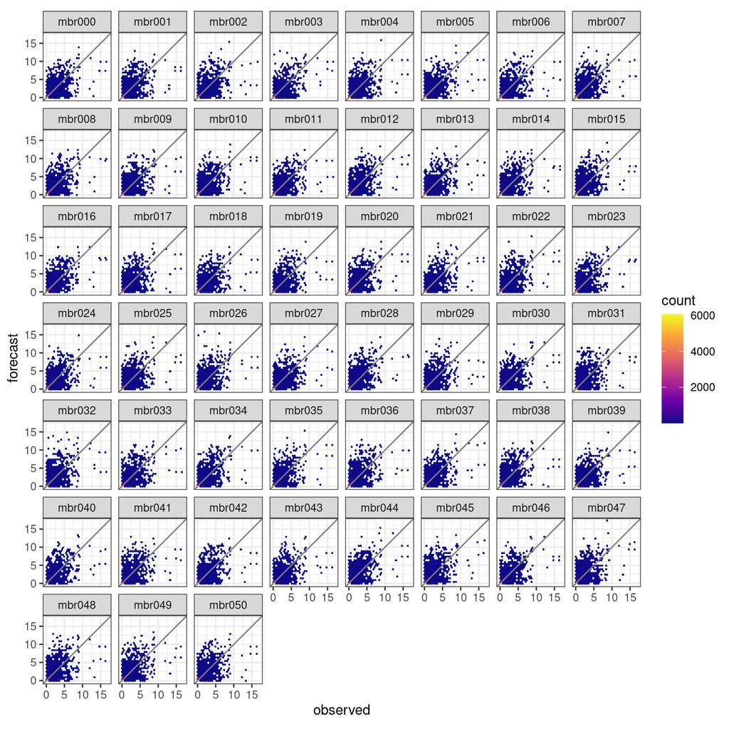

```r
plot_scatter(pcp6h, IFSENS, AccPcp6h)
```

Or you can combine all members by setting facet_members = FALSE

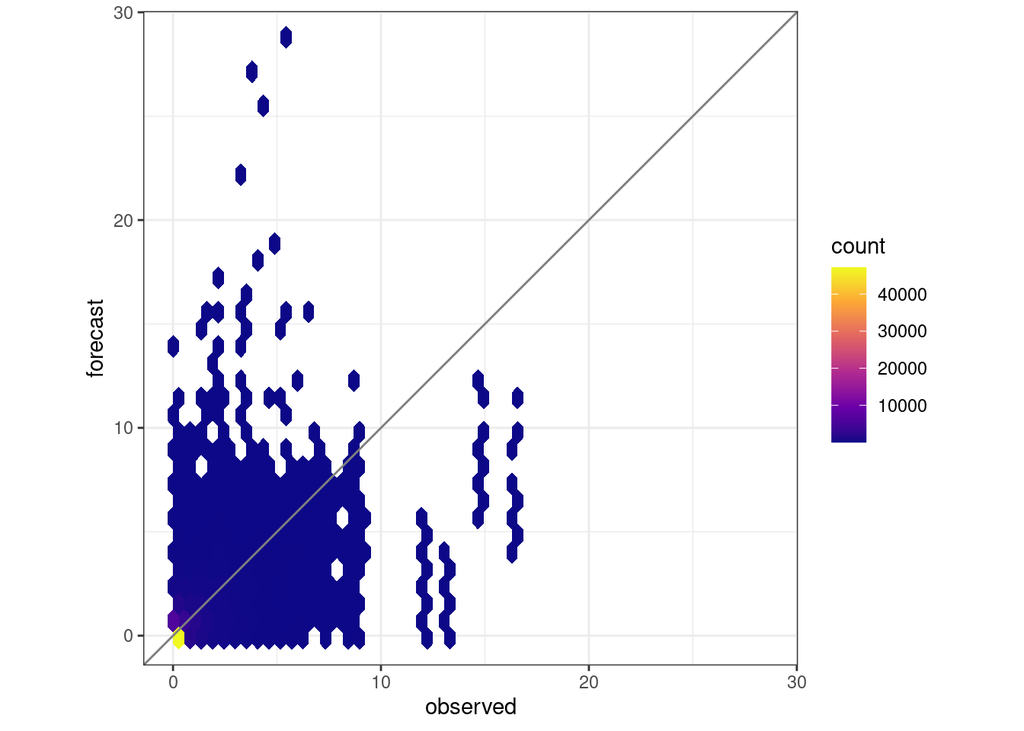

```r
plot_scatter(pcp6h, REF, AccPcp6h, facet_members = FALSE)
```

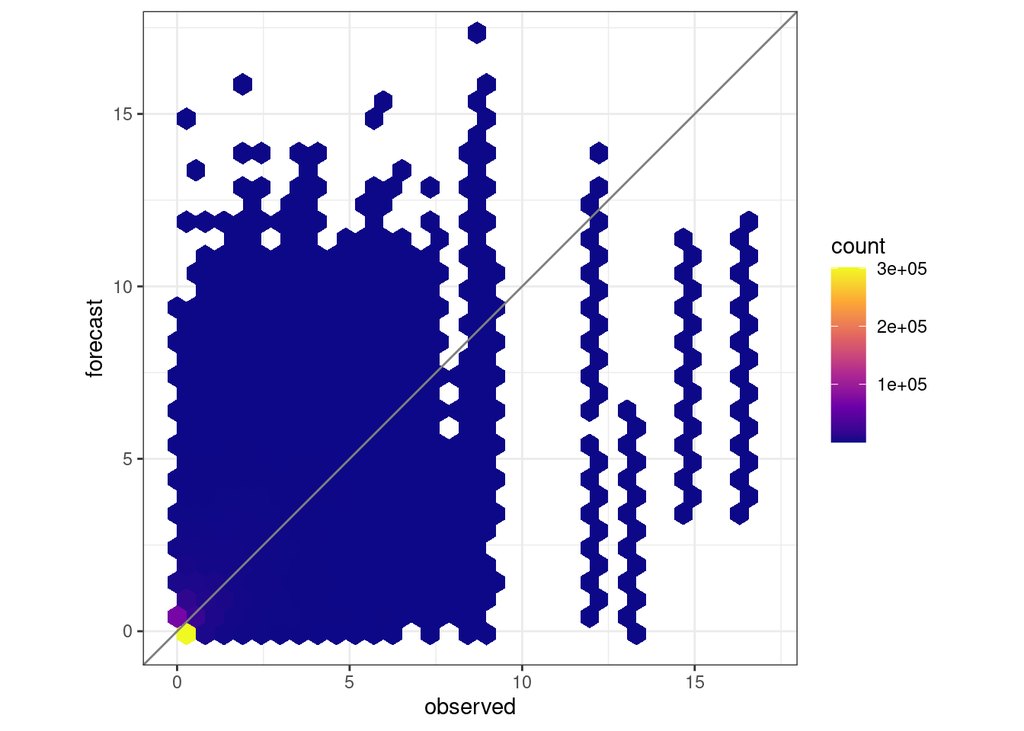

```r
plot_scatter(pcp6h, IFSENS, AccPcp6h, facet_members = FALSE)
```

And now verify with `ens_verify()`

```r
verif <- ens_verify(pcp6h, AccPcp6h)
```

And do some basic plots

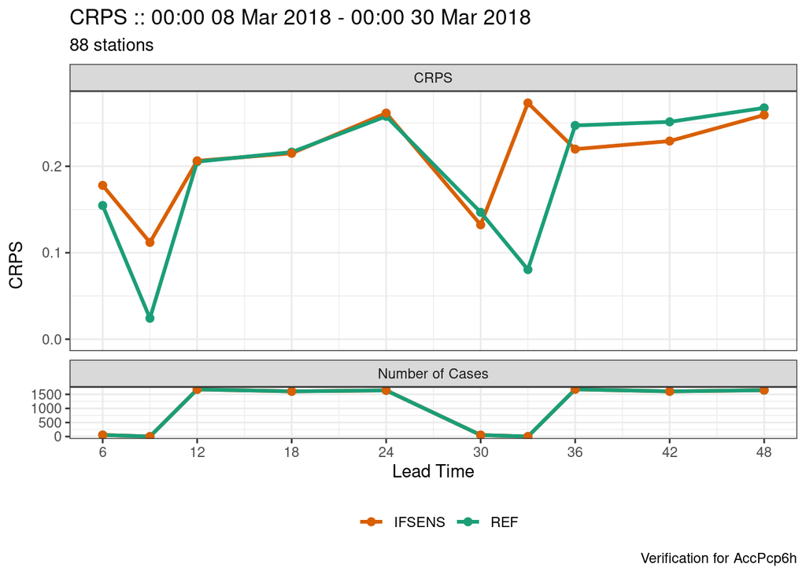

```r
plot_point_verif(verif, spread_skill)
plot_point_verif(verif, crps)
```

[output not shown]

We see that there are a number of lead times with very few cases - we can remove these using `filter_list()`

```r
verif <- filter_list(verif, num_cases > 100)
```

For rank histograms comparing models with different numbers of members is a bit ugly. However we can turn it into a relative rank histogram by setting `rank_is_relative = TRUE`. We can also normalize and change the plot type to a “lollipop” plot.

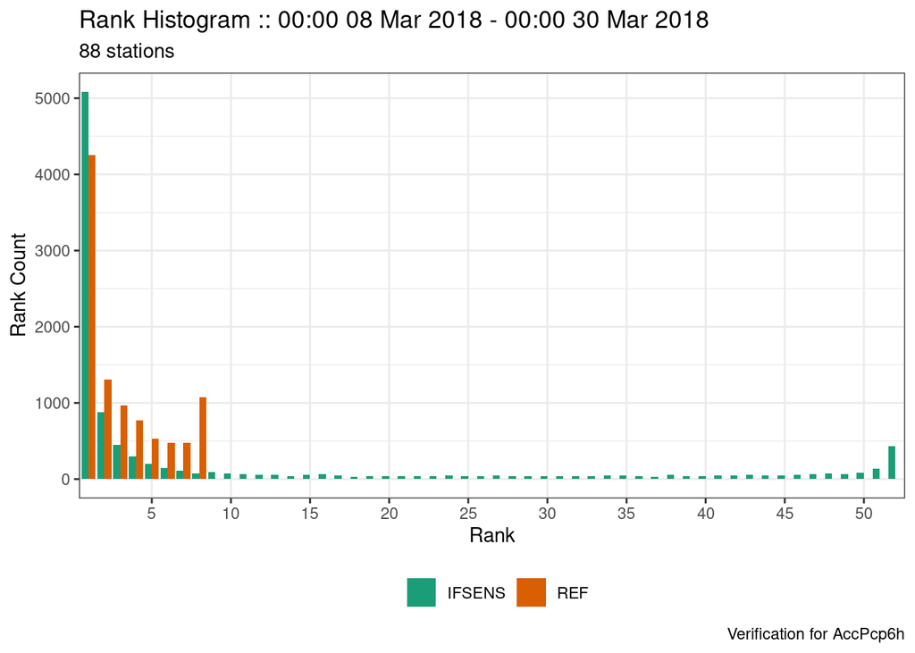

```r
plot_point_verif(verif, rank_histogram)
```

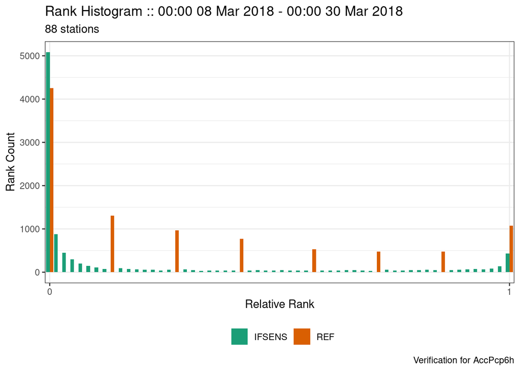

```r
plot_point_verif(verif, rank_histogram, rank_is_relative = TRUE)
```

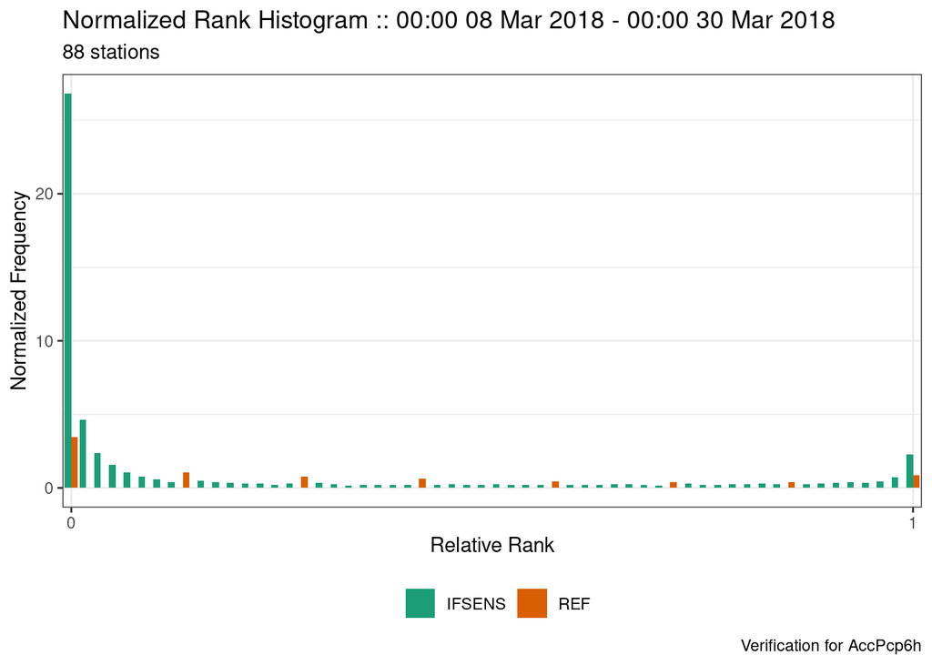

```r
plot_point_verif(verif, normalized_rank_histogram, rank_is_relative = TRUE)
```

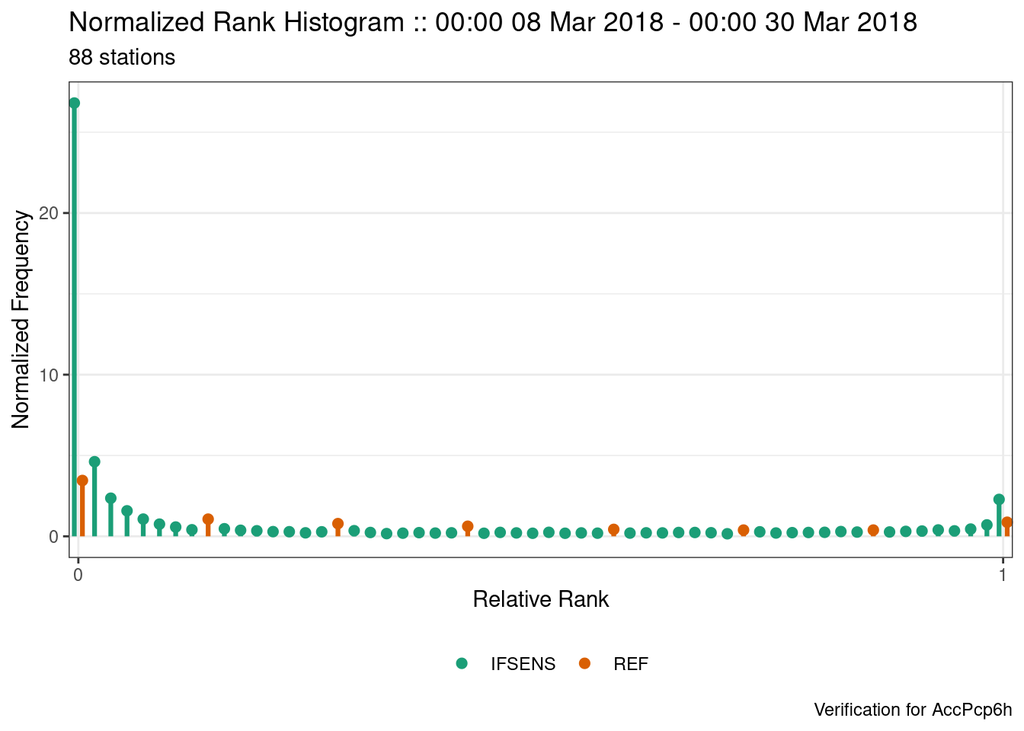

```r
plot_point_verif(
  verif, normalized_rank_histogram,
  rank_is_relative = TRUE, rank_hist_type = "lollipop"
)
```

By default, `ens_verify()` computes summary deterministic scores for each member, so we can plot those too, but things can get a bit difficult to see… so requires some extra work…

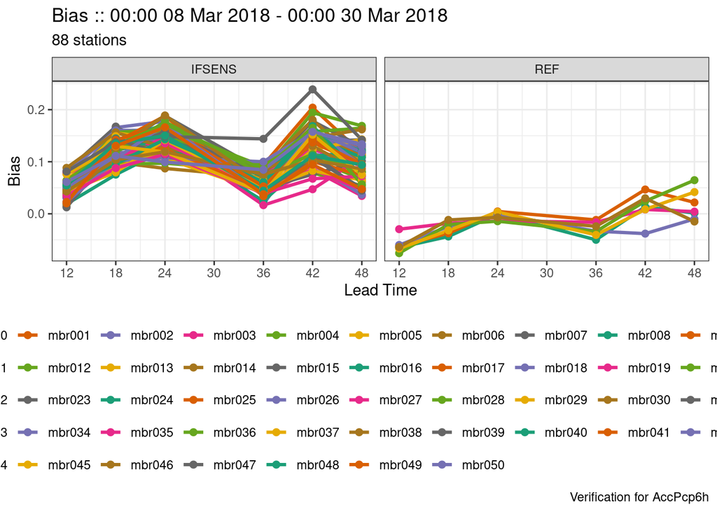

```r
plot_point_verif(
  verif,
  bias,
  verif_type = "det",
  colour_by = member,
  facet_by  = vars(mname),
  num_legend_rows = 5
)
```

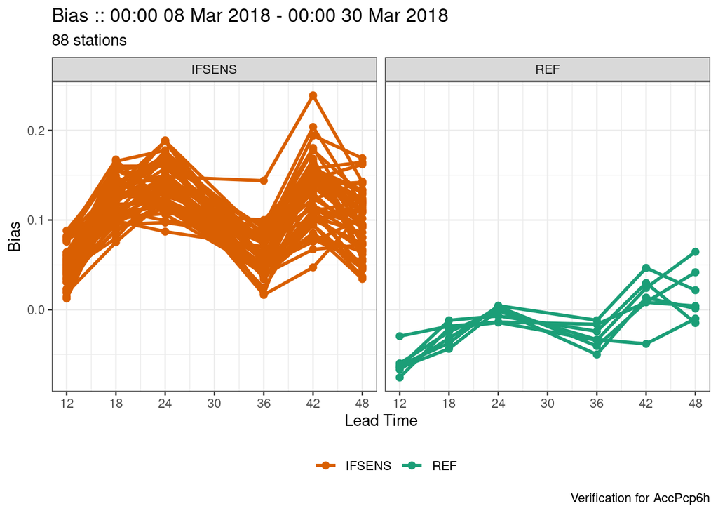

```r
plot_point_verif(
  verif,
  bias,
  verif_type = "det",
  group      = member,
  facet_by   = vars(mname)
)
```

So we need to tell it which is the control - we can use `mutate_list()` to mutate data frames in a harp verification object - if the columns you specify aren’t found it silently tries the next data frame. We `case_when()` to selectively mutate based on the contents of a column.

```r
verif <- mutate_list(
  verif,
  member_type = case_when(
    member == "mbr000" ~ "control",
    TRUE               ~ "perturbed"
  )
)
```

And now we can highlight the control member

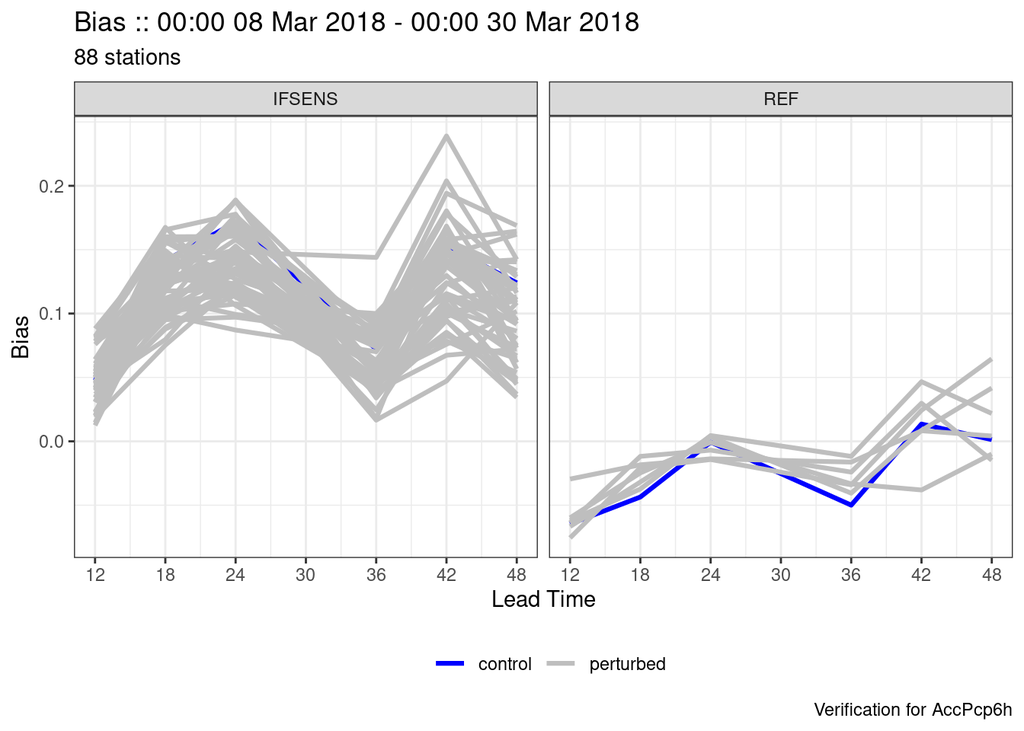

```r
plot_point_verif(
  verif,
  bias,
  verif_type = "det",
  colour_by  = member_type,
  group      = member,
  point_size = 0,
  facet_by   = vars(mname),
  colour_table = data.frame(
    member_type = c("control", "perturbed"),
    colour      = c("blue", "grey")
  )
)
```

The control member can look a bit hidden so we might have to draw it again.

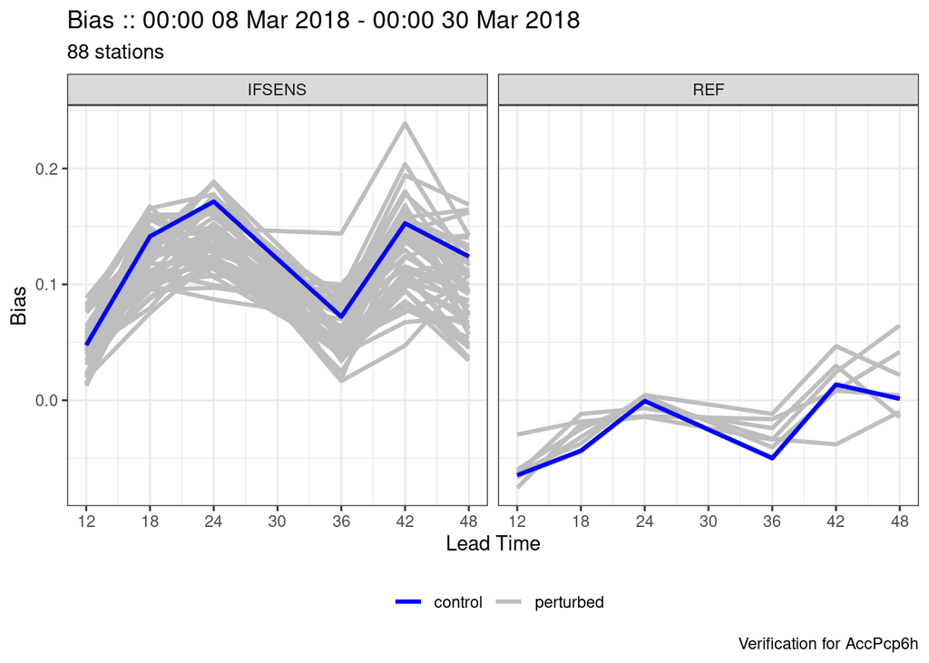

```r
plot_point_verif(
  verif,
  bias,
  verif_type = "det",
  colour_by  = member_type,
  group      = member,
  point_size = 0,
  facet_by   = vars(mname),
  colour_table = data.frame(
    member_type = c("control", "perturbed"),
    colour      = c("blue", "grey")
  )
) +
  geom_line(
    data   = filter(verif$det_summary_scores, member == "mbr000"),
    colour = "blue",
    size   = 1.1
  )
```

Like deterministic, we can compute categorical scores by adding some thresholds - we could get thresholds by computing quantiles of the observed quantities.

```r
thresholds <-quantile(pcp6h_obs$AccPcp6h, c(0.1, 0.25, 0.5, 0.75, 0.9))
thresholds
```

```
## 10% 25% 50% 75% 90%
## 0.0 0.0 0.0 0.3 1.2
```

There are a lot of zeroes, so maybe just do it on precip > 0

```r
thresholds <-quantile(
  filter(pcp6h_obs, AccPcp6h > 0)$AccPcp6h,
  c(0.1, 0.25, 0.5, 0.75, 0.9)
)
thresholds
```

```
##  10%  25%  50%  75%  90%
## 0.10 0.20 0.60 1.40 2.79
```

Now we verify with thresholds and we get a bunch of new scores

```r
verif <- ens_verify(pcp6h, AccPcp6h, thresholds = thresholds)
```

Again, when we plot we have to facet by threshold

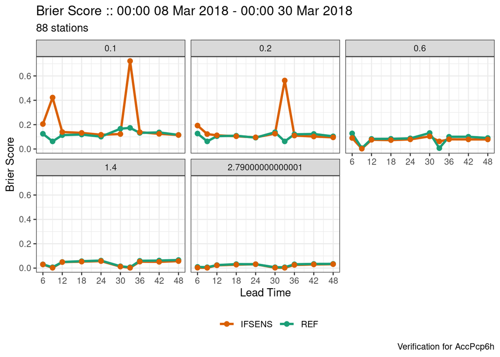

```r
plot_point_verif(verif, brier_score, facet_by = vars(threshold))
```

But let’s get rid of the points without much data - for threshold scores we need to filter on `num_cases_total`

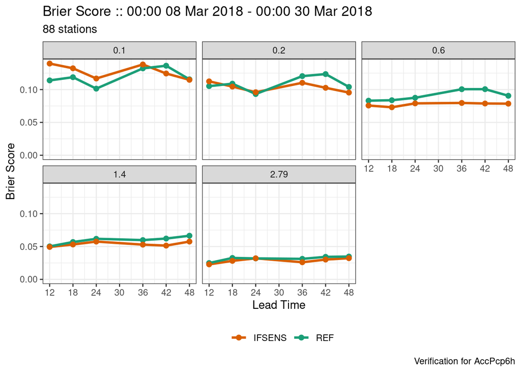

```r
verif <- filter_list(verif, num_cases_total > 100)
plot_point_verif(verif, brier_score, facet_by = vars(round(threshold, 2)))
```

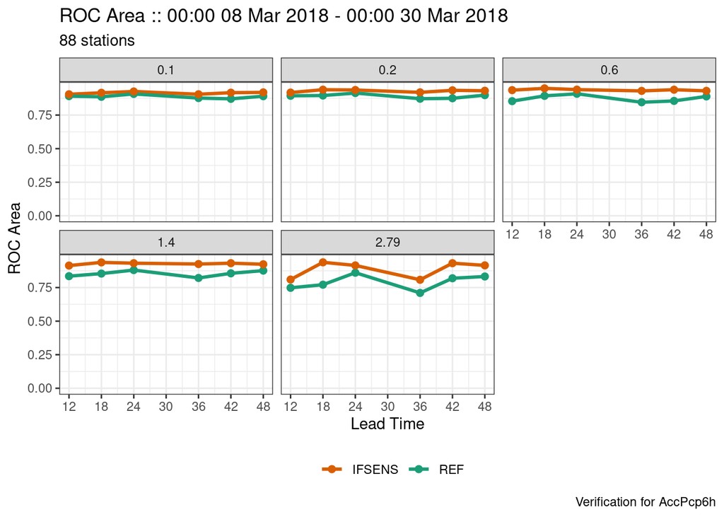

```r
plot_point_verif(verif, roc_area, facet_by = vars(round(threshold, 2)))
```

For some scores we need to filter / facet by lead time as well!

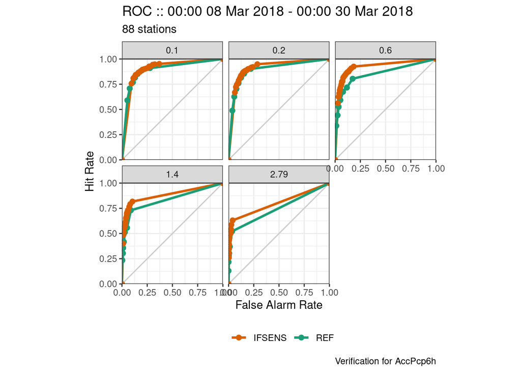

```r
plot_point_verif(
  verif, roc,
  facet_by = vars(round(threshold, 2)),
  filter_by = vars(leadtime == 12)
)
```

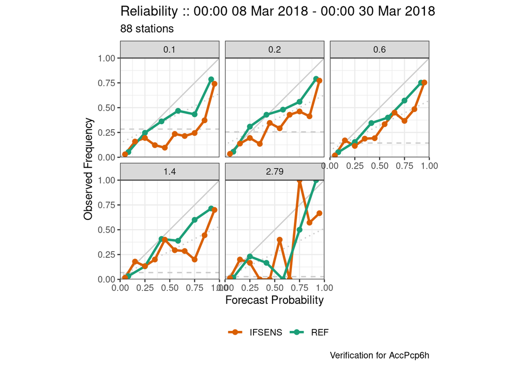

```r
plot_point_verif(
  verif, reliability,
  facet_by = vars(round(threshold, 2)),
  filter_by = vars(leadtime == 12)
)
```

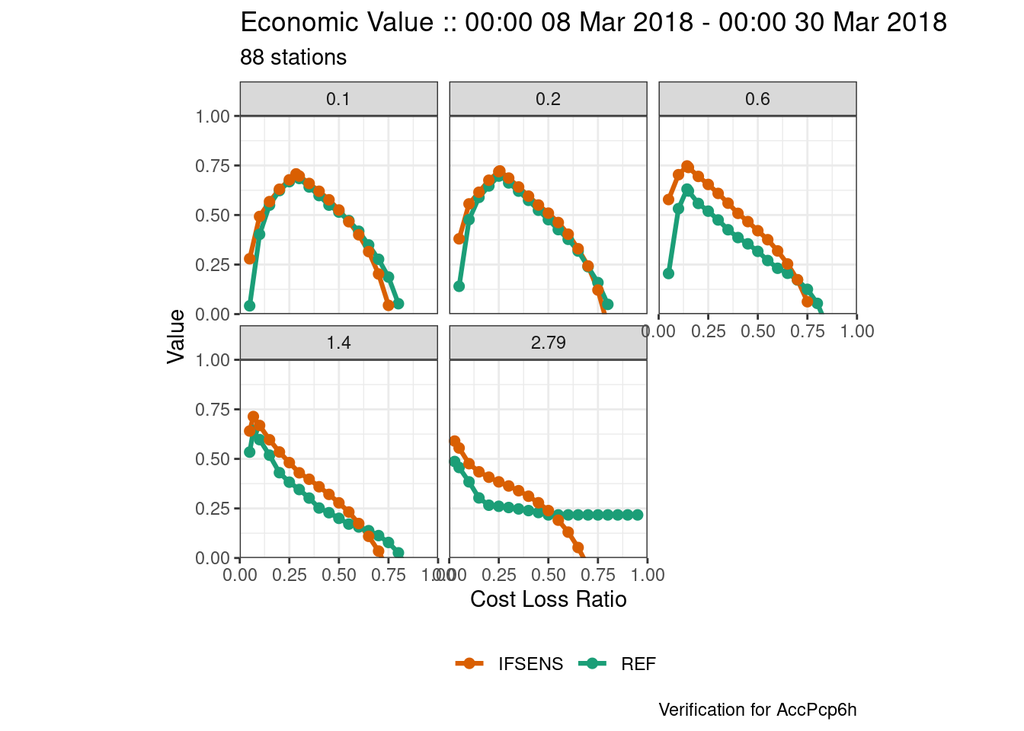

```r
plot_point_verif(
  verif, economic_value,
  facet_by = vars(round(threshold, 2)),
  filter_by = vars(leadtime == 12)
)
```

## Fair scores

Comparing models with different numbers of members is not a fair comparison. For some scores (CRPS and Brier Score), the scores can be scaled to what would be expected if the models had a certain number of ensemble members, or even infinite ensemble members. In `ens_verify()` this is done by adding something for the `num_ref_members` argument. Here we scale the scores so that both models have 51 members.

```r
verif <- ens_verify(
  pcp6h,
  AccPcp6h,
  thresholds      = thresholds,
  num_ref_members = 51
)
select_list(verif, mname, leadtime, matches("brier|crps|fair"))
```

```
## ::ens_summary_scores:: # A tibble: 20 × 17
##    fcst_model lead_time num_cases num_stations mean_bias   stde   rmse spread
##    <chr>          <int>     <int>        <int>     <dbl>  <dbl>  <dbl>  <dbl>
##  1 REF                6        56           28   0.104    0.482 0.489   0.356
##  2 REF                9         1            1   0.0821  NA     0.0821  0.130
##  3 REF               12      1676           88  -0.0603   0.705 0.707   0.381
##  4 REF               18      1607           88  -0.0269   0.668 0.668   0.468
##  5 REF               24      1641           88  -0.00405  0.890 0.890   0.518
##  6 REF               30        54           27   0.109    0.368 0.380   0.344
##  7 REF               33         1            1   0.257   NA     0.257   0.422
##  8 REF               36      1679           88  -0.0300   0.809 0.810   0.443
##  9 REF               42      1606           88   0.0133   0.768 0.768   0.678
## 10 REF               48      1648           88   0.0155   0.947 0.947   0.708
## 11 IFSENS             6        56           28   0.132    0.443 0.458   0.169
## 12 IFSENS             9         1            1   0.199   NA     0.199   0.167
## 13 IFSENS            12      1676           88   0.0491   0.667 0.669   0.246
## 14 IFSENS            18      1607           88   0.124    0.666 0.677   0.360
## 15 IFSENS            24      1641           88   0.139    0.854 0.865   0.400
## 16 IFSENS            30        54           27   0.0996   0.335 0.347   0.228
## 17 IFSENS            33         1            1   0.457   NA     0.457   0.354
## 18 IFSENS            36      1679           88   0.0626   0.744 0.746   0.399
## 19 IFSENS            42      1606           88   0.133    0.736 0.748   0.537
## 20 IFSENS            48      1648           88   0.0989   0.900 0.905   0.560
## # ℹ 9 more variables: dropped_members_spread <dbl>, spread_skill_ratio <dbl>,
## #   dropped_members_spread_skill_ratio <dbl>, hexbin <list>,
## #   rank_histogram <list>, fair_crps <dbl>, crps <dbl>, crps_potential <dbl>,
## #   crps_reliability <dbl>
##
## ::ens_threshold_scores:: # A tibble: 100 × 19
##    fcst_model lead_time threshold fair_brier_score sample_climatology
##    <chr>          <int>     <dbl>            <dbl>              <dbl>
##  1 REF                6       0.1           0.123               0.286
##  2 REF                9       0.1           0.0523              0
##  3 REF               12       0.1           0.111               0.284
##  4 REF               18       0.1           0.115               0.300
##  5 REF               24       0.1           0.0962              0.312
##  6 REF               30       0.1           0.154               0.296
##  7 REF               33       0.1           0.148               0
##  8 REF               36       0.1           0.126               0.279
##  9 REF               42       0.1           0.128               0.307
```

[output cut: 14 more lines]

```
##  4 REF        REF       mbr000        18      1607           88 -0.0436   0.723
##  5 REF        REF       mbr000        24      1641           88 -0.000642 1.01
##  6 REF        REF       mbr000        30        54           27  0.0777   0.368
##  7 REF        REF       mbr000        33         1            1  0.168    0.168
##  8 REF        REF       mbr000        36      1679           88 -0.0500   0.888
##  9 REF        REF       mbr000        42      1606           88  0.0135   0.893
## 10 REF        REF       mbr000        48      1648           88  0.00132  1.10
## # ℹ 570 more rows
## # ℹ 3 more variables: mae <dbl>, stde <dbl>, hexbin <list>
##
## --harp verification for AccPcp6h--
##  # for forecasts from 00:00 UTC 08 Mar 2018 to 00:00 UTC 30 Mar 2018
##  # using 88 observation stations
##  # for verification groups:
##     -> lead_time
```

Or we can scale both models to have an infinite number of members (only works for CRPS)

```r
verif <- ens_verify(
  pcp6h,
  AccPcp6h,
  thresholds      = thresholds,
  num_ref_members = Inf
)
select_list(verif, mname, leadtime, matches("brier|crps|fair"))
```

```
## ::ens_summary_scores:: # A tibble: 20 × 17
##    fcst_model lead_time num_cases num_stations mean_bias   stde   rmse spread
##    <chr>          <int>     <int>        <int>     <dbl>  <dbl>  <dbl>  <dbl>
##  1 REF                6        56           28   0.104    0.482 0.489   0.356
##  2 REF                9         1            1   0.0821  NA     0.0821  0.130
##  3 REF               12      1676           88  -0.0603   0.705 0.707   0.381
##  4 REF               18      1607           88  -0.0269   0.668 0.668   0.468
##  5 REF               24      1641           88  -0.00405  0.890 0.890   0.518
##  6 REF               30        54           27   0.109    0.368 0.380   0.344
##  7 REF               33         1            1   0.257   NA     0.257   0.422
##  8 REF               36      1679           88  -0.0300   0.809 0.810   0.443
##  9 REF               42      1606           88   0.0133   0.768 0.768   0.678
## 10 REF               48      1648           88   0.0155   0.947 0.947   0.708
## 11 IFSENS             6        56           28   0.132    0.443 0.458   0.169
## 12 IFSENS             9         1            1   0.199   NA     0.199   0.167
## 13 IFSENS            12      1676           88   0.0491   0.667 0.669   0.246
## 14 IFSENS            18      1607           88   0.124    0.666 0.677   0.360
## 15 IFSENS            24      1641           88   0.139    0.854 0.865   0.400
## 16 IFSENS            30        54           27   0.0996   0.335 0.347   0.228
## 17 IFSENS            33         1            1   0.457   NA     0.457   0.354
## 18 IFSENS            36      1679           88   0.0626   0.744 0.746   0.399
## 19 IFSENS            42      1606           88   0.133    0.736 0.748   0.537
## 20 IFSENS            48      1648           88   0.0989   0.900 0.905   0.560
## # ℹ 9 more variables: dropped_members_spread <dbl>, spread_skill_ratio <dbl>,
## #   dropped_members_spread_skill_ratio <dbl>, hexbin <list>,
## #   rank_histogram <list>, fair_crps <dbl>, crps <dbl>, crps_potential <dbl>,
## #   crps_reliability <dbl>
##
## ::ens_threshold_scores:: # A tibble: 100 × 19
##    fcst_model lead_time threshold fair_brier_score sample_climatology
##    <chr>          <int>     <dbl>            <dbl>              <dbl>
##  1 REF                6       0.1              NaN              0.286
##  2 REF                9       0.1              NaN              0
##  3 REF               12       0.1              NaN              0.284
##  4 REF               18       0.1              NaN              0.300
##  5 REF               24       0.1              NaN              0.312
##  6 REF               30       0.1              NaN              0.296
##  7 REF               33       0.1              NaN              0
##  8 REF               36       0.1              NaN              0.279
##  9 REF               42       0.1              NaN              0.307
```

[output cut: 14 more lines]

```
##  4 REF        REF       mbr000        18      1607           88 -0.0436   0.723
##  5 REF        REF       mbr000        24      1641           88 -0.000642 1.01
##  6 REF        REF       mbr000        30        54           27  0.0777   0.368
##  7 REF        REF       mbr000        33         1            1  0.168    0.168
##  8 REF        REF       mbr000        36      1679           88 -0.0500   0.888
##  9 REF        REF       mbr000        42      1606           88  0.0135   0.893
## 10 REF        REF       mbr000        48      1648           88  0.00132  1.10
## # ℹ 570 more rows
## # ℹ 3 more variables: mae <dbl>, stde <dbl>, hexbin <list>
##
## --harp verification for AccPcp6h--
##  # for forecasts from 00:00 UTC 08 Mar 2018 to 00:00 UTC 30 Mar 2018
##  # using 88 observation stations
##  # for verification groups:
##     -> lead_time
```

# Individual scores

If you only want to compute individual scores you can use the specific functions

```r
ens_spread_and_skill(pcp6h, AccPcp6h)
```

```
## ::Computing verification for fcst_model `REF`::
```

```
## Spread; Skill for lead_time✔
## ::Computing verification for fcst_model `IFSENS`::
## Spread; Skill for lead_time✔
```

```
## ::ens_summary_scores:: # A tibble: 20 × 11
##    fcst_model lead_time num_cases num_stations mean_bias   stde   rmse spread
##    <chr>          <int>     <int>        <int>     <dbl>  <dbl>  <dbl>  <dbl>
##  1 REF                6        56           28   0.104    0.482 0.489   0.356
##  2 REF                9         1            1   0.0821  NA     0.0821  0.130
##  3 REF               12      1676           88  -0.0603   0.705 0.707   0.381
##  4 REF               18      1607           88  -0.0269   0.668 0.668   0.468
##  5 REF               24      1641           88  -0.00405  0.890 0.890   0.518
##  6 REF               30        54           27   0.109    0.368 0.380   0.344
##  7 REF               33         1            1   0.257   NA     0.257   0.422
##  8 REF               36      1679           88  -0.0300   0.809 0.810   0.443
##  9 REF               42      1606           88   0.0133   0.768 0.768   0.678
## 10 REF               48      1648           88   0.0155   0.947 0.947   0.708
## 11 IFSENS             6        56           28   0.132    0.443 0.458   0.169
## 12 IFSENS             9         1            1   0.199   NA     0.199   0.167
## 13 IFSENS            12      1676           88   0.0491   0.667 0.669   0.246
## 14 IFSENS            18      1607           88   0.124    0.666 0.677   0.360
## 15 IFSENS            24      1641           88   0.139    0.854 0.865   0.400
## 16 IFSENS            30        54           27   0.0996   0.335 0.347   0.228
## 17 IFSENS            33         1            1   0.457   NA     0.457   0.354
## 18 IFSENS            36      1679           88   0.0626   0.744 0.746   0.399
## 19 IFSENS            42      1606           88   0.133    0.736 0.748   0.537
## 20 IFSENS            48      1648           88   0.0989   0.900 0.905   0.560
## # ℹ 3 more variables: dropped_members_spread <dbl>, spread_skill_ratio <dbl>,
## #   dropped_members_spread_skill_ratio <dbl>
##
## --harp verification for AccPcp6h--
##  # for forecasts from 00:00 UTC 08 Mar 2018 to 00:00 UTC 30 Mar 2018
##  # using 88 observation stations
##  # for verification groups:
##     -> lead_time
```

```
## ℹ use `attributes()` to see detailed metadata
```

```r
ens_crps(pcp6h, AccPcp6h)
```

```
## ::Computing verification for fcst_model `REF`::
## CRPS for lead_time✔
## ::Computing verification for fcst_model `IFSENS`::
## CRPS for lead_time✔
```

```
## ::ens_summary_scores:: # A tibble: 20 × 7
##    fcst_model lead_time num_cases num_stations   crps crps_potential
##    <chr>          <int>     <int>        <int>  <dbl>          <dbl>
##  1 REF                6        56           28 0.155    0.0954
##  2 REF                9         1            1 0.0242   0
##  3 REF               12      1676           88 0.205    0.177
##  4 REF               18      1607           88 0.216    0.190
##  5 REF               24      1641           88 0.258    0.224
##  6 REF               30        54           27 0.147    0.104
##  7 REF               33         1            1 0.0805   0.0000128
##  8 REF               36      1679           88 0.247    0.214
##  9 REF               42      1606           88 0.251    0.224
## 10 REF               48      1648           88 0.268    0.240
## 11 IFSENS            12      1676           88 0.206    0.159
## 12 IFSENS            18      1607           88 0.215    0.165
## 13 IFSENS            24      1641           88 0.261    0.201
## 14 IFSENS            30        54           27 0.132    0.0967
## 15 IFSENS            36      1679           88 0.220    0.189
## 16 IFSENS            42      1606           88 0.229    0.193
## 17 IFSENS            48      1648           88 0.259    0.226
## 18 IFSENS             6        56           28 0.178    0.107
## 19 IFSENS            33         1            1 0.273    0
## 20 IFSENS             9         1            1 0.112    0.0000000751
## # ℹ 1 more variable: crps_reliability <dbl>
##
## --harp verification for AccPcp6h--
##  # for forecasts from 00:00 UTC 08 Mar 2018 to 00:00 UTC 30 Mar 2018
##  # using 88 observation stations
##  # for verification groups:
##     -> lead_time
```

```
## ℹ use `attributes()` to see detailed metadata
```

```r
ens_rank_histogram(pcp6h, AccPcp6h)
```

```
## ::Computing verification for fcst_model `REF`::
## Rank histogram for lead_time✔
## ::Computing verification for fcst_model `IFSENS`::
## Rank histogram for lead_time✔
```

```
## ::ens_summary_scores:: # A tibble: 20 × 4
##    fcst_model lead_time num_stations rank_histogram
##    <chr>          <int>        <int> <list>
##  1 REF                6           28 <tibble [8 × 3]>
##  2 REF                9            1 <tibble [8 × 3]>
##  3 REF               12           88 <tibble [8 × 3]>
##  4 REF               18           88 <tibble [8 × 3]>
##  5 REF               24           88 <tibble [8 × 3]>
##  6 REF               30           27 <tibble [8 × 3]>
##  7 REF               33            1 <tibble [8 × 3]>
##  8 REF               36           88 <tibble [8 × 3]>
##  9 REF               42           88 <tibble [8 × 3]>
## 10 REF               48           88 <tibble [8 × 3]>
## 11 IFSENS            12           88 <tibble [52 × 3]>
## 12 IFSENS            18           88 <tibble [52 × 3]>
## 13 IFSENS            24           88 <tibble [52 × 3]>
## 14 IFSENS            30           27 <tibble [52 × 3]>
## 15 IFSENS            36           88 <tibble [52 × 3]>
## 16 IFSENS            42           88 <tibble [52 × 3]>
## 17 IFSENS            48           88 <tibble [52 × 3]>
## 18 IFSENS             6           28 <tibble [52 × 3]>
## 19 IFSENS            33            1 <tibble [52 × 3]>
## 20 IFSENS             9            1 <tibble [52 × 3]>
##
## --harp verification for AccPcp6h--
##  # for forecasts from 00:00 UTC 08 Mar 2018 to 00:00 UTC 30 Mar 2018
##  # using 88 observation stations
##  # for verification groups:
##     -> lead_time
```

```
## ℹ use `attributes()` to see detailed metadata
```

```r
ens_brier(pcp6h, AccPcp6h, thresholds = thresholds)
```

```
## ::Computing verification for fcst_model `REF`::
## Brier Score for lead_time & threshold✔
## ::Computing verification for fcst_model `IFSENS`::
## Brier Score for lead_time & threshold✔
```

```
## ::ens_threshold_scores:: # A tibble: 100 × 16
##    fcst_model lead_time threshold fair_brier_score sample_climatology
##    <chr>          <int>     <dbl>            <dbl>              <dbl>
##  1 REF                6       0.1           0.130               0.286
##  2 REF                9       0.1           0.0816              0
##  3 REF               12       0.1           0.117               0.284
##  4 REF               18       0.1           0.122               0.300
##  5 REF               24       0.1           0.104               0.312
##  6 REF               30       0.1           0.165               0.296
##  7 REF               33       0.1           0.184               0
##  8 REF               36       0.1           0.135               0.279
##  9 REF               42       0.1           0.137               0.307
## 10 REF               48       0.1           0.117               0.308
## # ℹ 90 more rows
## # ℹ 11 more variables: bss_ref_climatology <dbl>, num_stations <int>,
## #   num_cases_total <int>, num_cases_observed <int>, num_cases_forecast <int>,
## #   brier_score <dbl>, brier_skill_score <dbl>, brier_score_reliability <dbl>,
## #   brier_score_resolution <dbl>, brier_score_uncertainty <dbl>,
## #   reliability <list>
##
## --harp verification for AccPcp6h--
##  # for forecasts from 00:00 UTC 08 Mar 2018 to 00:00 UTC 30 Mar 2018
##  # using 88 observation stations
##  # for verification groups:
##     -> lead_time & threshold
```

```
## ℹ use `attributes()` to see detailed metadata
```

```r
ens_reliability(pcp6h, AccPcp6h, thresholds = thresholds)
```

```
## ::Computing verification for fcst_model `REF`::
## Brier Score for lead_time & threshold✔
## ::Computing verification for fcst_model `IFSENS`::
## Brier Score for lead_time & threshold✔
```

```
## ::ens_threshold_scores:: # A tibble: 100 × 11
##    fcst_model lead_time threshold fair_brier_score sample_climatology
##    <chr>          <int>     <dbl>            <dbl>              <dbl>
##  1 REF                6       0.1           0.130               0.286
##  2 REF                9       0.1           0.0816              0
##  3 REF               12       0.1           0.117               0.284
##  4 REF               18       0.1           0.122               0.300
##  5 REF               24       0.1           0.104               0.312
##  6 REF               30       0.1           0.165               0.296
##  7 REF               33       0.1           0.184               0
##  8 REF               36       0.1           0.135               0.279
##  9 REF               42       0.1           0.137               0.307
## 10 REF               48       0.1           0.117               0.308
## # ℹ 90 more rows
## # ℹ 6 more variables: bss_ref_climatology <dbl>, num_stations <int>,
## #   num_cases_total <int>, num_cases_observed <int>, num_cases_forecast <int>,
## #   reliability <list>
##
## --harp verification for AccPcp6h--
##  # for forecasts from 00:00 UTC 08 Mar 2018 to 00:00 UTC 30 Mar 2018
##  # using 88 observation stations
##  # for verification groups:
##     -> lead_time & threshold
```

```
## ℹ use `attributes()` to see detailed metadata
```

```r
ens_roc(pcp6h, AccPcp6h, thresholds = thresholds)
```

```
## ::Computing verification for fcst_model `REF`::
## ROC for lead_time & threshold✔
## ::Computing verification for fcst_model `IFSENS`::
## ROC for lead_time & threshold✔
```

```
## ::ens_threshold_scores:: # A tibble: 100 × 6
##    fcst_model lead_time threshold num_stations roc               roc_area
##    <chr>          <int>     <dbl>        <int> <list>               <dbl>
##  1 REF                6       0.1           28 <tibble [21 × 3]>    0.866
##  2 REF                9       0.1            1 <tibble [21 × 3]>   NA
##  3 REF               12       0.1           88 <tibble [21 × 3]>    0.891
##  4 REF               18       0.1           88 <tibble [21 × 3]>    0.886
##  5 REF               24       0.1           88 <tibble [21 × 3]>    0.907
##  6 REF               30       0.1           27 <tibble [21 × 3]>    0.831
##  7 REF               33       0.1            1 <tibble [21 × 3]>   NA
##  8 REF               36       0.1           88 <tibble [21 × 3]>    0.877
##  9 REF               42       0.1           88 <tibble [21 × 3]>    0.871
## 10 REF               48       0.1           88 <tibble [21 × 3]>    0.891
## # ℹ 90 more rows
##
## --harp verification for AccPcp6h--
##  # for forecasts from 00:00 UTC 08 Mar 2018 to 00:00 UTC 30 Mar 2018
##  # using 88 observation stations
##  # for verification groups:
##     -> lead_time & threshold
```

```
## ℹ use `attributes()` to see detailed metadata
```

```r
ens_value(pcp6h, AccPcp6h, thresholds = thresholds)
```

```
## ::Computing verification for fcst_model `REF`::
## Econ Value for lead_time & threshold✔
## ::Computing verification for fcst_model `IFSENS`::
## Econ Value for lead_time & threshold✔
```

```
## ::ens_threshold_scores:: # A tibble: 100 × 5
##    fcst_model lead_time threshold num_stations economic_value
##    <chr>          <int>     <dbl>        <int> <list>
##  1 REF                6       0.1           28 <tibble [20 × 2]>
##  2 REF                9       0.1            1 <tibble [20 × 2]>
##  3 REF               12       0.1           88 <tibble [20 × 2]>
##  4 REF               18       0.1           88 <tibble [20 × 2]>
##  5 REF               24       0.1           88 <tibble [20 × 2]>
##  6 REF               30       0.1           27 <tibble [20 × 2]>
##  7 REF               33       0.1            1 <tibble [20 × 2]>
##  8 REF               36       0.1           88 <tibble [20 × 2]>
##  9 REF               42       0.1           88 <tibble [20 × 2]>
## 10 REF               48       0.1           88 <tibble [20 × 2]>
## # ℹ 90 more rows
##
## --harp verification for AccPcp6h--
##  # for forecasts from 00:00 UTC 08 Mar 2018 to 00:00 UTC 30 Mar 2018
##  # using 88 observation stations
##  # for verification groups:
##     -> lead_time & threshold
```

```
## ℹ use `attributes()` to see detailed metadata
```

The outputs always have the same format no matter the score.